# Wine Quality

```
## 'data.frame':    1599 obs. of  13 variables:
##  $ X                   : int  1 2 3 4 5 6 7 8 9 10 ...
##  $ fixed.acidity       : num  7.4 7.8 7.8 11.2 7.4 7.4 7.9 7.3 7.8 7.5 ...
##  $ volatile.acidity    : num  0.7 0.88 0.76 0.28 0.7 0.66 0.6 0.65 0.58 0.5 ...
##  $ citric.acid         : num  0 0 0.04 0.56 0 0 0.06 0 0.02 0.36 ...
##  $ residual.sugar      : num  1.9 2.6 2.3 1.9 1.9 1.8 1.6 1.2 2 6.1 ...
##  $ chlorides           : num  0.076 0.098 0.092 0.075 0.076 0.075 0.069 0.065 0.073 0.071 ...
##  $ free.sulfur.dioxide : num  11 25 15 17 11 13 15 15 9 17 ...
##  $ total.sulfur.dioxide: num  34 67 54 60 34 40 59 21 18 102 ...
##  $ density             : num  0.998 0.997 0.997 0.998 0.998 ...
##  $ pH                  : num  3.51 3.2 3.26 3.16 3.51 3.51 3.3 3.39 3.36 3.35 ...
##  $ sulphates           : num  0.56 0.68 0.65 0.58 0.56 0.56 0.46 0.47 0.57 0.8 ...
##  $ alcohol             : num  9.4 9.8 9.8 9.8 9.4 9.4 9.4 10 9.5 10.5 ...
##  $ quality             : int  5 5 5 6 5 5 5 7 7 5 ...
```

```
##        X          fixed.acidity   volatile.acidity  citric.acid
##  Min.   :   1.0   Min.   : 4.60   Min.   :0.1200   Min.   :0.000
##  1st Qu.: 400.5   1st Qu.: 7.10   1st Qu.:0.3900   1st Qu.:0.090
##  Median : 800.0   Median : 7.90   Median :0.5200   Median :0.260
##  Mean   : 800.0   Mean   : 8.32   Mean   :0.5278   Mean   :0.271
##  3rd Qu.:1199.5   3rd Qu.: 9.20   3rd Qu.:0.6400   3rd Qu.:0.420
##  Max.   :1599.0   Max.   :15.90   Max.   :1.5800   Max.   :1.000
##  residual.sugar     chlorides       free.sulfur.dioxide
##  Min.   : 0.900   Min.   :0.01200   Min.   : 1.00
##  1st Qu.: 1.900   1st Qu.:0.07000   1st Qu.: 7.00
##  Median : 2.200   Median :0.07900   Median :14.00
##  Mean   : 2.539   Mean   :0.08747   Mean   :15.87
##  3rd Qu.: 2.600   3rd Qu.:0.09000   3rd Qu.:21.00
##  Max.   :15.500   Max.   :0.61100   Max.   :72.00
##  total.sulfur.dioxide    density             pH          sulphates
##  Min.   :  6.00       Min.   :0.9901   Min.   :2.740   Min.   :0.3300
##  1st Qu.: 22.00       1st Qu.:0.9956   1st Qu.:3.210   1st Qu.:0.5500
##  Median : 38.00       Median :0.9968   Median :3.310   Median :0.6200
##  Mean   : 46.47       Mean   :0.9967   Mean   :3.311   Mean   :0.6581
##  3rd Qu.: 62.00       3rd Qu.:0.9978   3rd Qu.:3.400   3rd Qu.:0.7300
##  Max.   :289.00       Max.   :1.0037   Max.   :4.010   Max.   :2.0000
##     alcohol         quality
##  Min.   : 8.40   Min.   :3.000
##  1st Qu.: 9.50   1st Qu.:5.000
##  Median :10.20   Median :6.000
##  Mean   :10.42   Mean   :5.636
##  3rd Qu.:11.10   3rd Qu.:6.000
##  Max.   :14.90   Max.   :8.000
```

The wine dataset contains 13 variables and 1599 observations. I will look at the factors that affect the wine quality.

# Univariate Plots Section

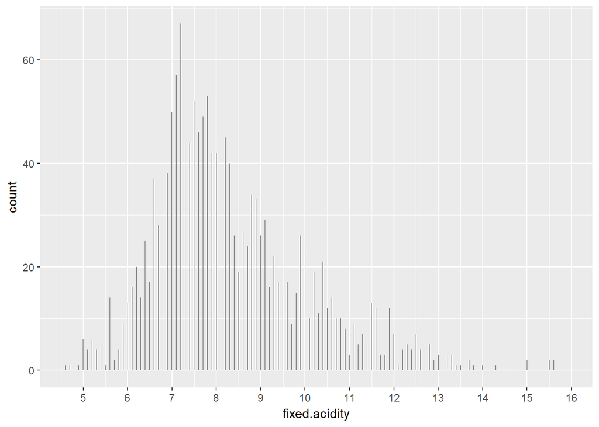

```
##    Min. 1st Qu.  Median    Mean 3rd Qu.    Max.
##    4.60    7.10    7.90    8.32    9.20   15.90
```

Most of the wine has fixed acidity quantity around 7 g/dm^3. It would be interesting to see how the quantity of fixed acidity fair with the quality of the wine.

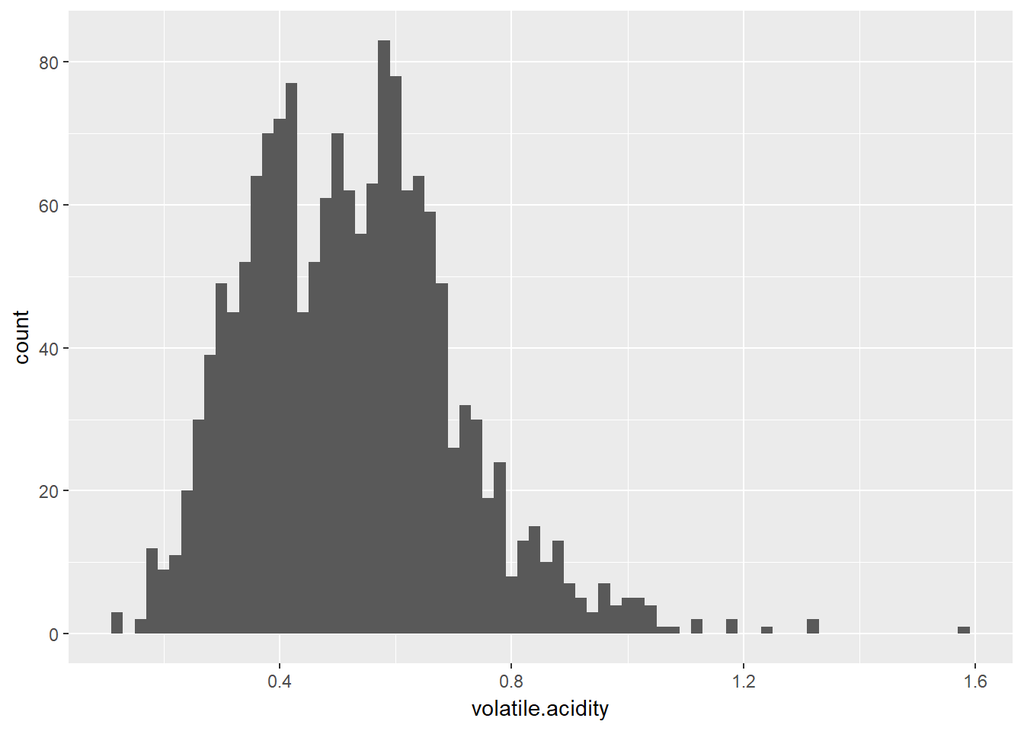

It’s a bi-modal distribution. We will have to see if this type of distribution has an impact on the quality.

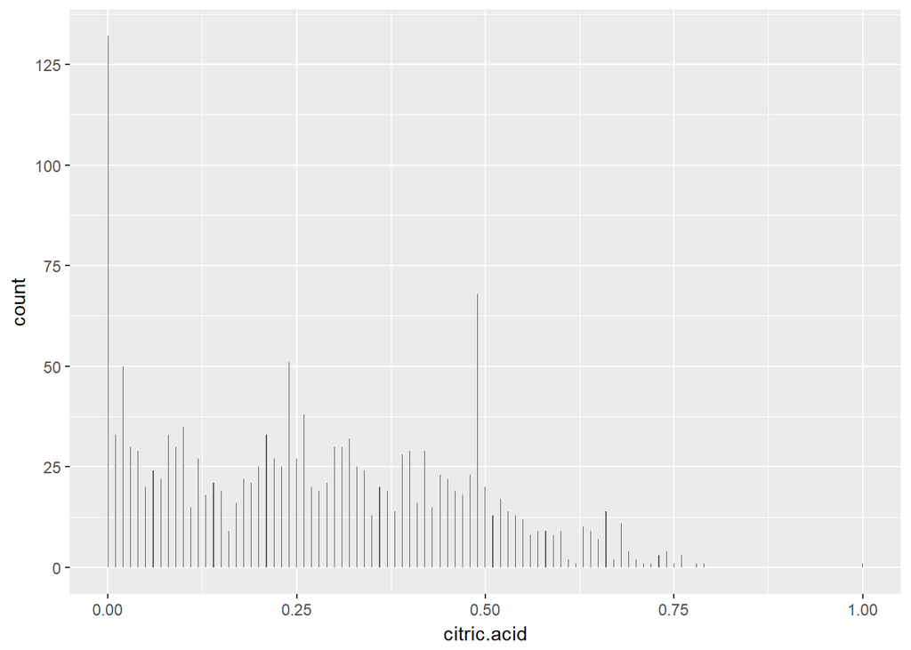

```
## [1] 0 1
```

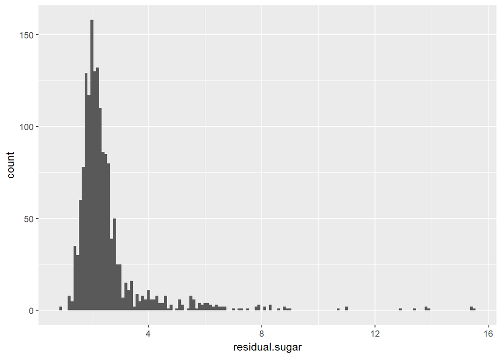

A normal distribution with lots of Outliers. It would be interesting to know about the outliers quality.

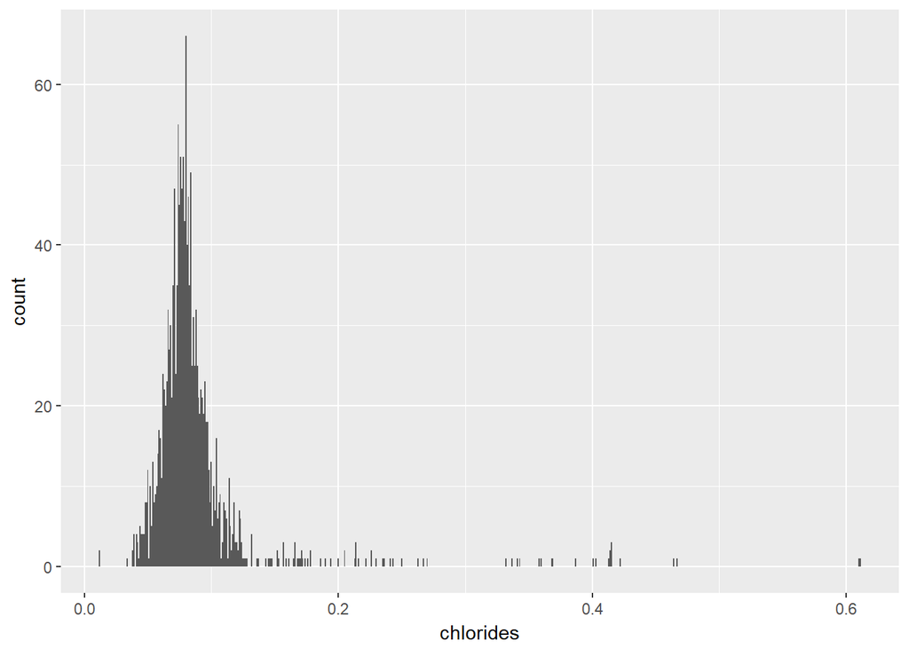

Sodium chloride is a salt. Most of the wine has less than 0.1 g/dm^3. With few outliers. I wonder what would be the quality of the wine which has chloride quantity more than 0.6 g/dm^3.

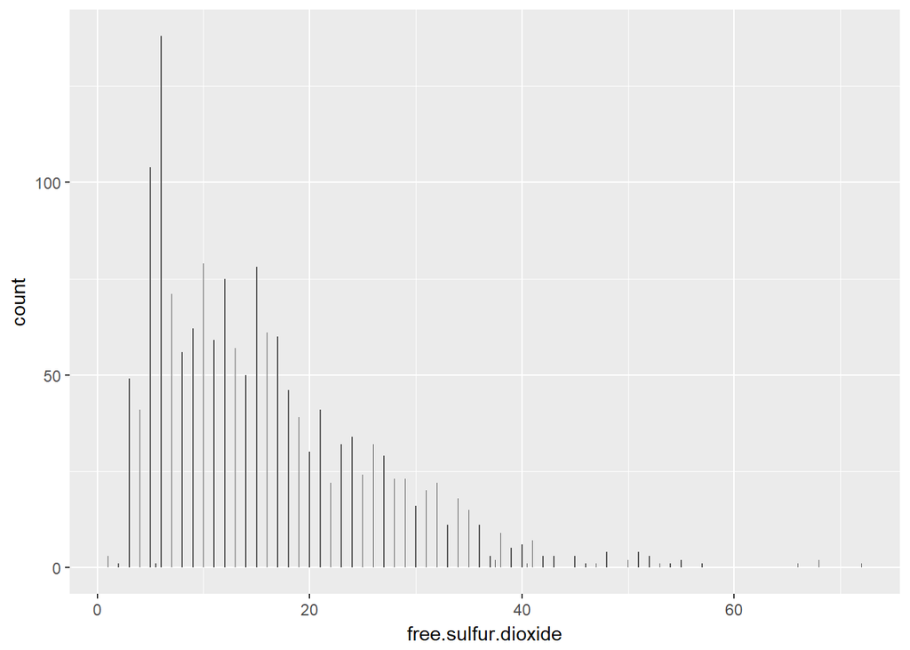

Free sulfur dioxide data is skewed. Should we transform the data?

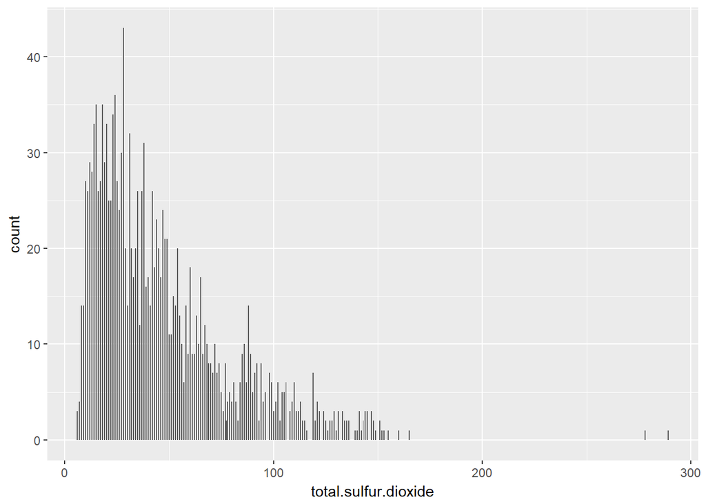

Both free sulfur dioxide and total sulfur dioxide’s data is skewed. How strong is Is it correlation with the free sulfur dioxide?

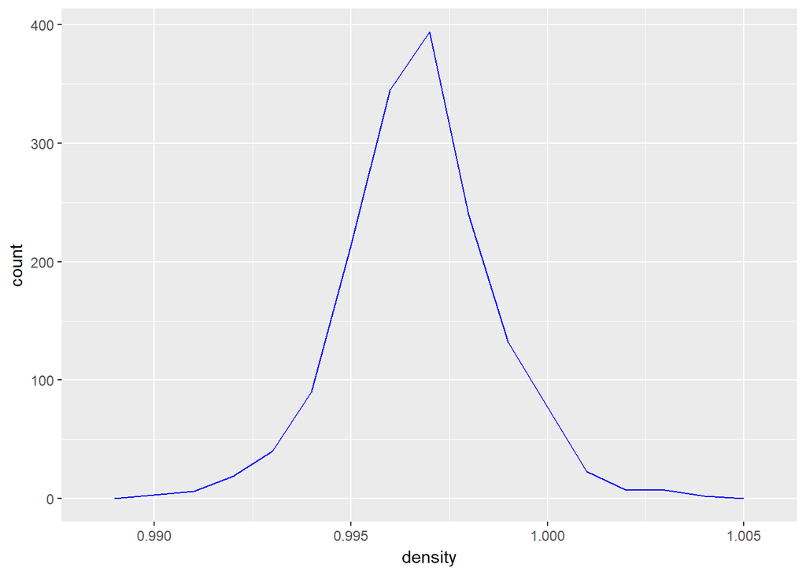

Does density have any effect on the quality score of the wine?

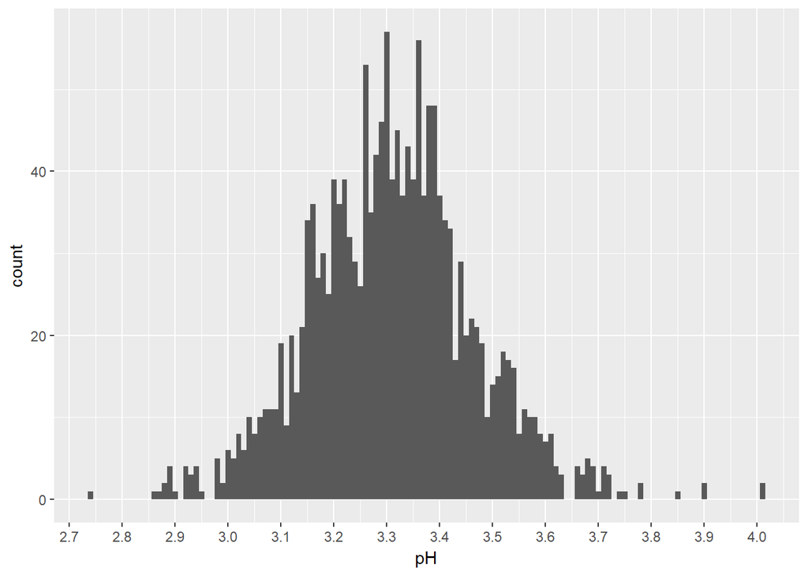

A bulk of the wine has a pH between 3.15 and 3.45. I wonder what this plot might look like across the quality of the wine. Does the pH have any effect on the quality of the wine? There are a few outliers, it would be interesting to know about their quality too.

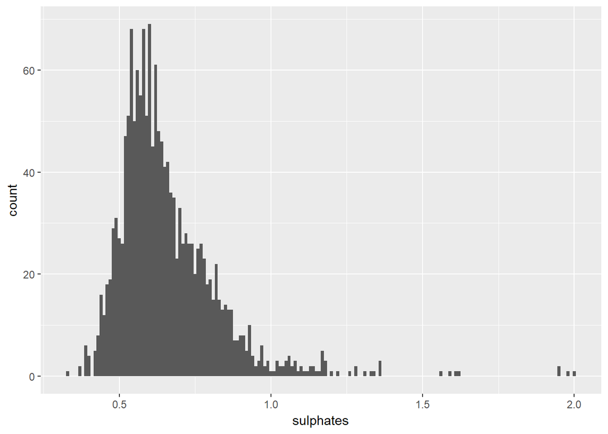

Sulphates are used as antioxidant, I think it might have a strong correlation with the quality.

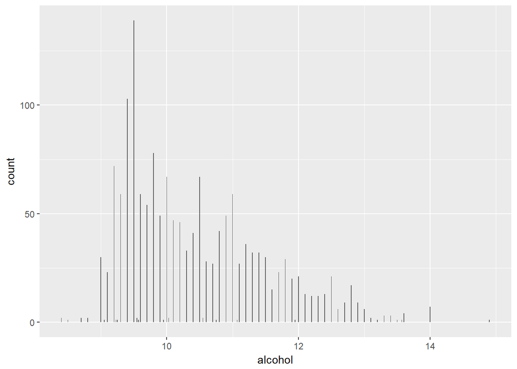

Little skewed. It would be nice to see how it fairs with the quality of the wine. A lot of wine have below 10. How does the below 10 and above 10 vary with quality?

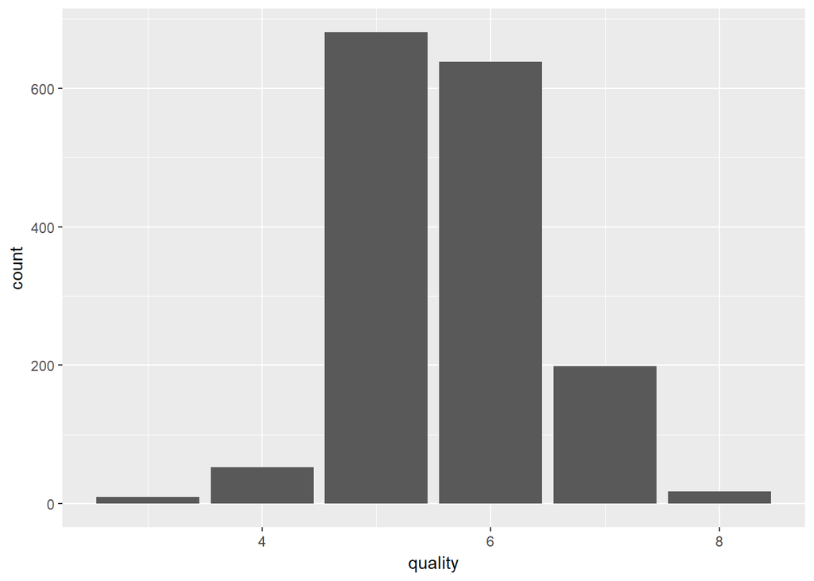

The data in quality is an integer. A bulk of the rating is either 5 or 6. Will be interesting to know whether the variables have the same observation where the quality is 5 or 6.

```r
# Create a categorical variable
wine$quality_category <- cut(wine$quality, c(3,5,8), labels = c('low', 'high'))
```

I created a categorical variable that will help in visualizing in a more appropriate way.

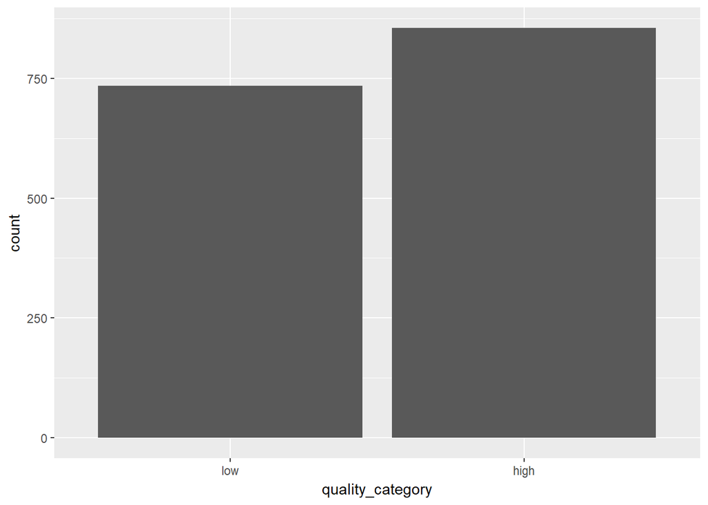

So, most of the wines fit into the high category.

# Univariate Analysis

### What is the structure of your dataset?

The dataset has 13 variables and 1599 observations. Variables are the chemical property of the wine. Most of the variables are normally distributed. There was one variable with bi-modal distribution - Volatile Acidity. Free sulfur dioxide and total sulfur dioxide data is skewed. And most of the variables do have outliers too.

### What other features in the dataset do you think will help support your investigation into your feature(s) of interest?

pH level in the best quality of alcohol will be worth observing. Outliers in most of the variables would be worth investigating.

### Of the features you investigated, were there any unusual distributions? Did you perform any operations on the data to tidy, adjust, or change the form of the data? If so, why did you do this?

Some plot didn’t look like a normal distribution with default binwidth, so I adjusted the binwidth which gave a better shape to the plot (normal distribution). Adjusting the binwidth also helped me in getting a bi-modal distribution which looked like a normal distribution with default binwidth.

# Bivariate Plots Section

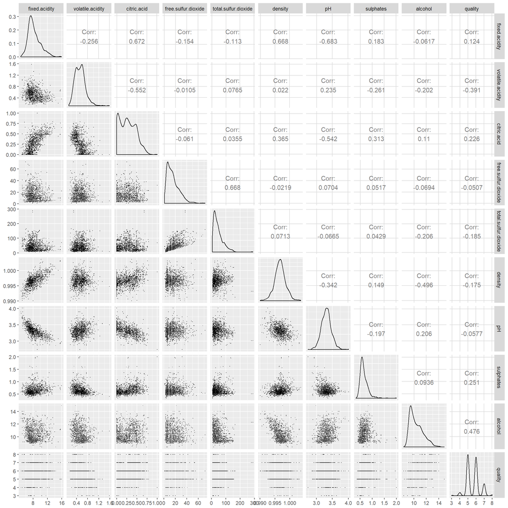

As per the plot matrix, we can see the correlation between variables. Some of the interesting correlation is between alcohol and quality, alcohol and density and volatile acidity.

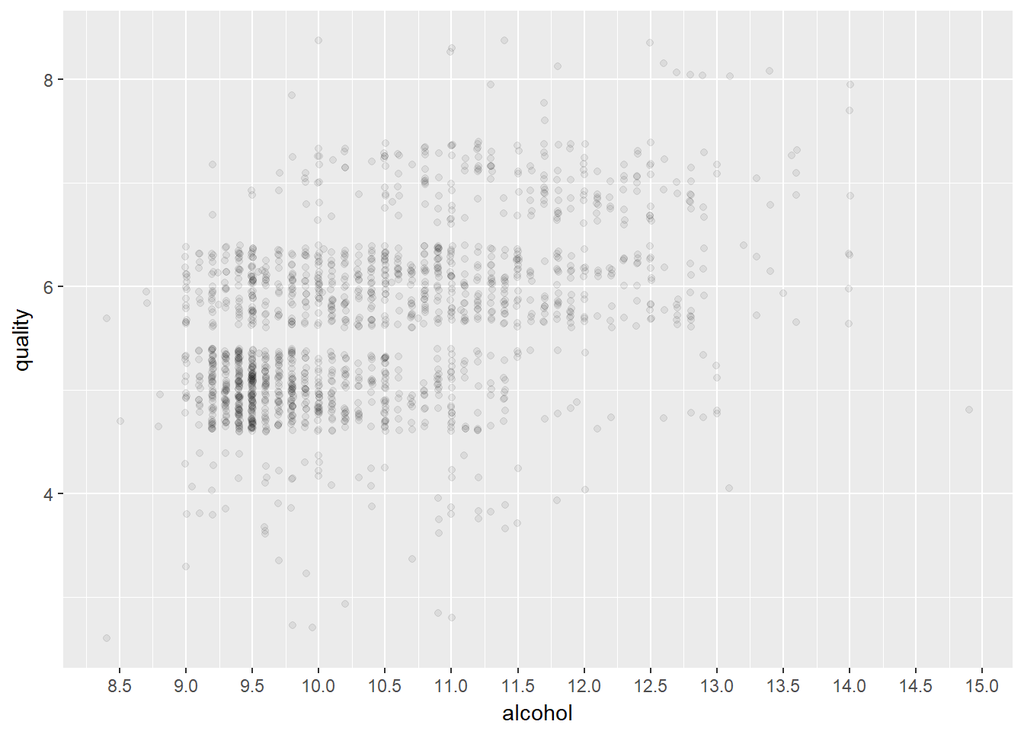

I added jitter for better visual.

From the above scatterplot, we can say that alcohol percentage greater than 9.5 might result in as a good quality wine. However, the percentage of alcohol solely doesn’t result in a better quality.

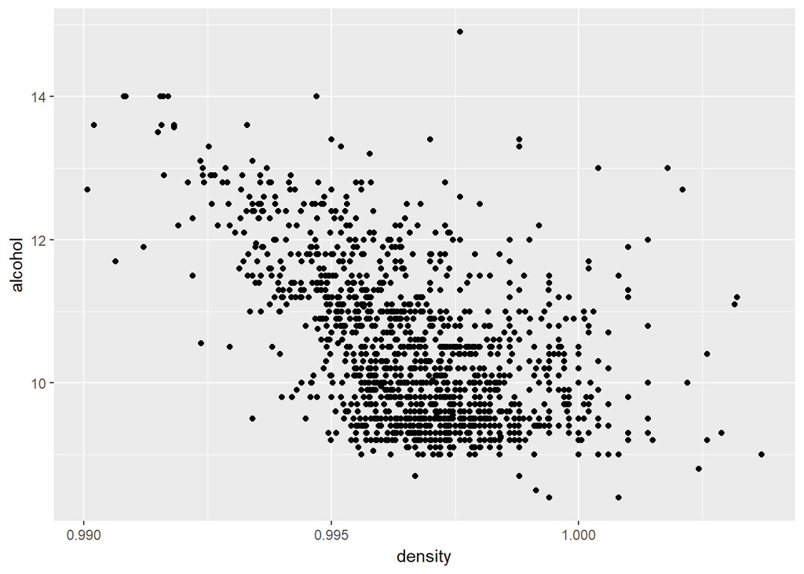

Density and alcohol correlation was a stronger one in our plot matrix and we can see it here.

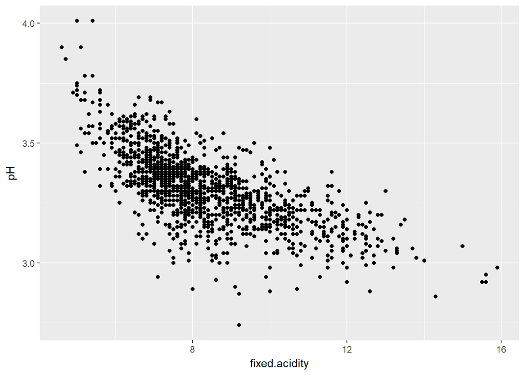

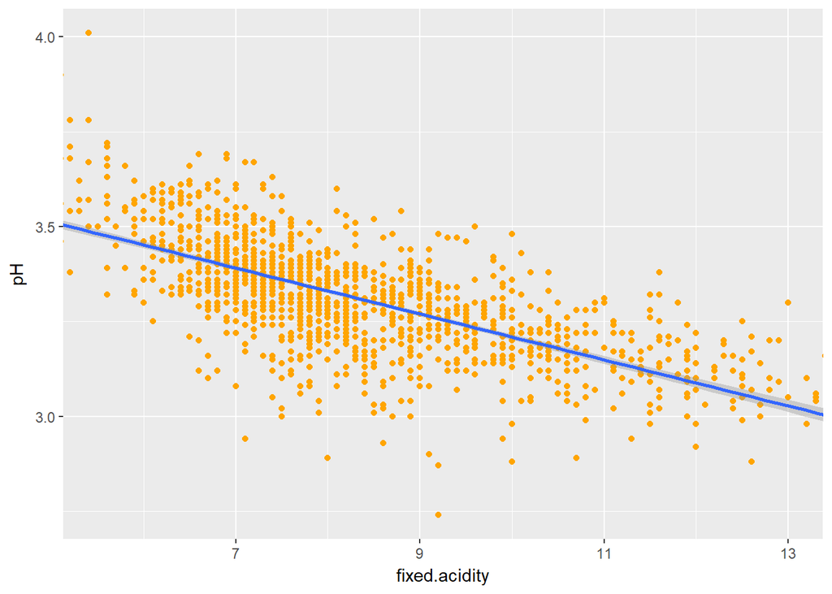

Re-plotting the above plot. Like our earlier finding in plot matrix they do have a strong correlation.

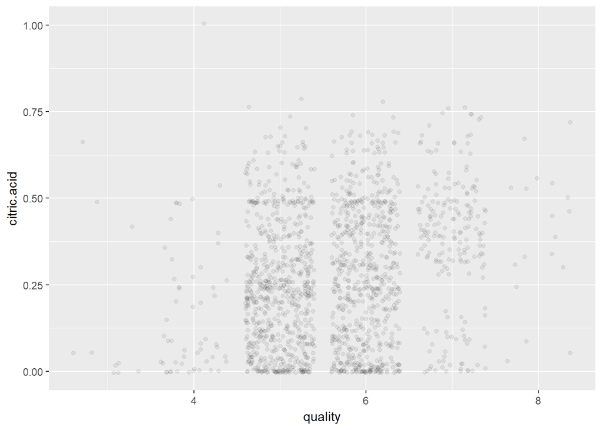

Not a single wine got a quality score as 8, when the citric acid is 0.

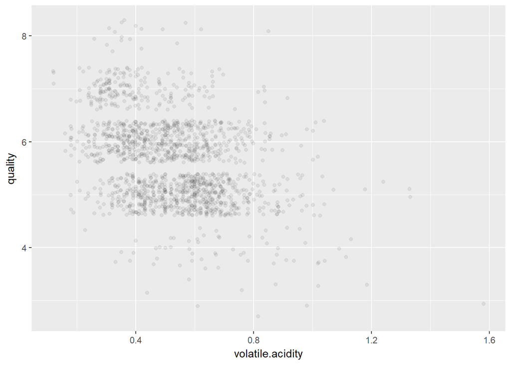

Lesser the volatile acidity better the quality.

# Bivariate Analysis

### Talk about some of the relationships you observed in this part of the investigation. How did the feature(s) of interest vary with other features in the dataset?

Citric acid and quality of the wine are not strongly correlated. At first, I thought it might be a big factor. Quality is correlated with the alcohol, pH has a correlation with the citric acid and fixed acidity. The quality is correlated with the percentage of alcohol. It would be interesting to see what percentage of alcohol makes a wine of good quality.

### Did you observe any interesting relationships between the other features (not the main feature(s) of interest)?

Residual sugar doesn’t have a strong correlation with any variable. So I removed it from the plot matrix.

### What was the strongest relationship you found?

The strongest relationship was between fixed acidity and pH with -0.683.

# Multivariate Plots Section

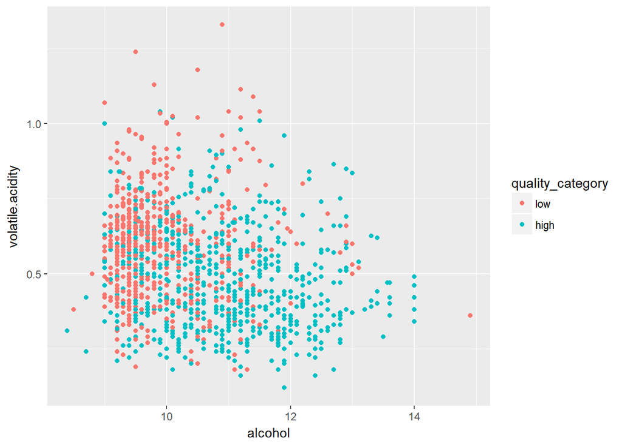

This plot strengthens out previous assumption - if the alcohol percentage it more then, the quality might be better.

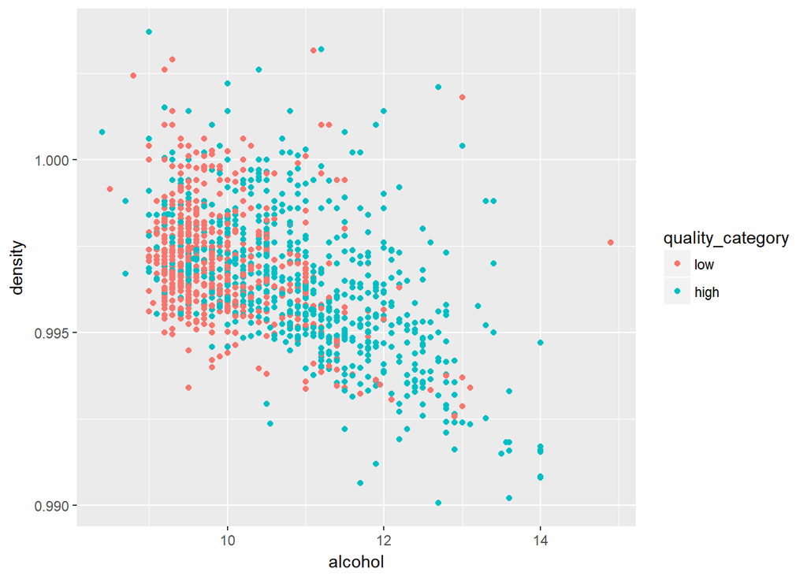

It justifies our earlier finding in the plot matrix, where there was a strong correlation between the density and the alcohol and although there is a strong correlation between alcohol and the quality it doesn’t necessarily mean the density and quality have a strong correlation.

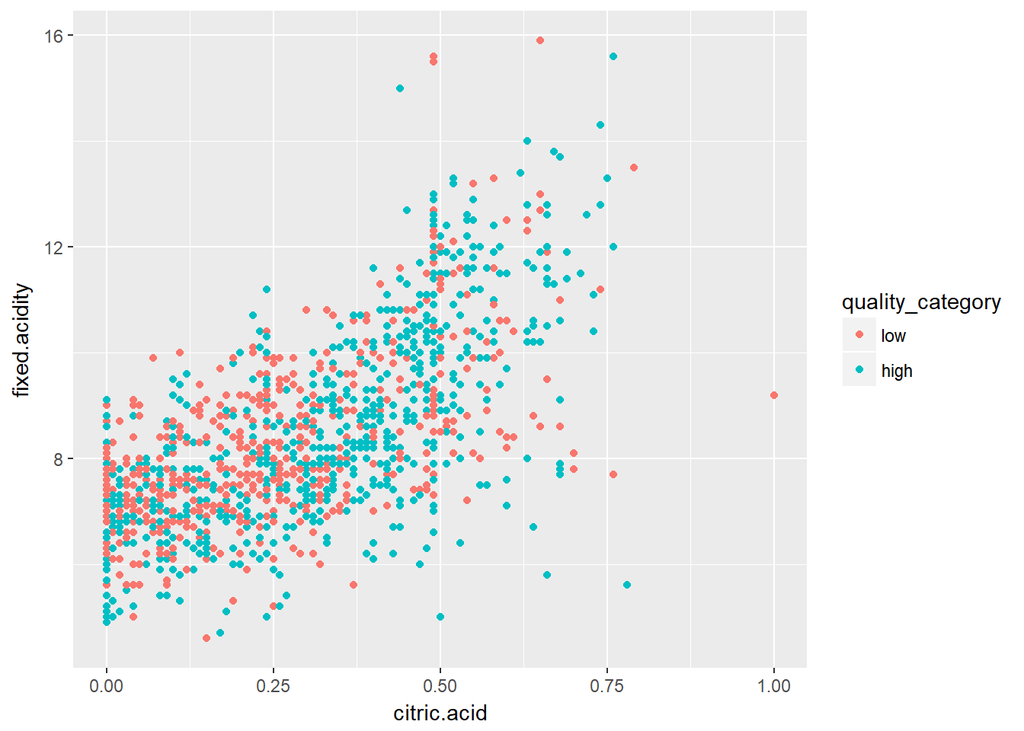

The quality category seems to be all over the place. There doesn’t seem to be any strong correlation between the quality and the other two variables. However the fixed acidity and citric acid are strongly correlated.

```
##
## Calls:
## m1: lm(formula = I(quality) ~ I(alcohol), data = wine)
## m2: lm(formula = I(quality) ~ I(alcohol) + volatile.acidity, data = wine)
## m3: lm(formula = I(quality) ~ I(alcohol) + volatile.acidity + sulphates,
##     data = wine)
## m4: lm(formula = I(quality) ~ I(alcohol) + volatile.acidity + sulphates +
##     citric.acid, data = wine)
##
## ============================================================================
##                          m1            m2            m3            m4
## ----------------------------------------------------------------------------
##   (Intercept)           1.875***      3.095***      2.611***      2.646***
##                        (0.175)       (0.184)       (0.196)       (0.201)
##   I(alcohol)            0.361***      0.314***      0.309***      0.309***
##                        (0.017)       (0.016)       (0.016)       (0.016)
##   volatile.acidity                   -1.384***     -1.221***     -1.265***
##                                      (0.095)       (0.097)       (0.113)
##   sulphates                                         0.679***      0.696***
##                                                    (0.101)       (0.103)
##   citric.acid                                                    -0.079
##                                                                  (0.104)
## ----------------------------------------------------------------------------
##   R-squared             0.227         0.317         0.336         0.336
##   adj. R-squared        0.226         0.316         0.335         0.334
##   sigma                 0.710         0.668         0.659         0.659
##   F                   468.267       370.379       268.912       201.777
##   p                     0.000         0.000         0.000         0.000
##   Log-likelihood    -1721.057     -1621.814     -1599.384     -1599.093
##   Deviance            805.870       711.796       692.105       691.852
##   AIC                3448.114      3251.628      3208.768      3210.186
##   BIC                3464.245      3273.136      3235.654      3242.448
##   N                  1599          1599          1599          1599
## ============================================================================
```

# Multivariate Analysis

### Talk about some of the relationships you observed in this part of the investigation. Were there features that strengthened each other in terms of looking at your feature(s) of interest?

The two clear variables that do contributes to the quality of wine are the percentage of alcohol and volatile acidity. Other variables don’t strongly explain the variability in the quality of the wine.

### Were there any interesting or surprising interactions between features?

Volatile acidity had a strong correlation with citric acid, and as volatile acidity explains the variability of the quality, I thought citric acid will also have an impact on the quality but that wasn’t to be.

### OPTIONAL: Did you create any models with your dataset? Discuss the strengths and limitations of your model.

Yes, I did create models, it helped me justify the variability of quality of the wine due to various variables.

Strengths:

Very simple to use and comprehend the result.

Limitations:

Linear regression is very sensitive to the anomalies in the data.

# Final Plots and Summary

### Plot One

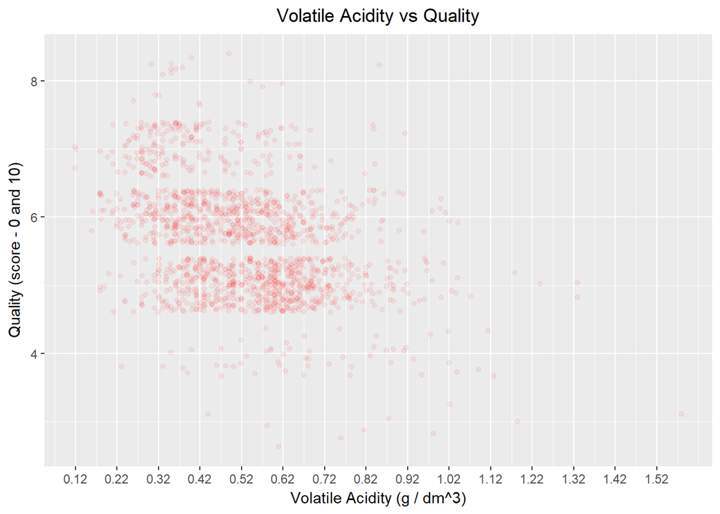

### Plot Two

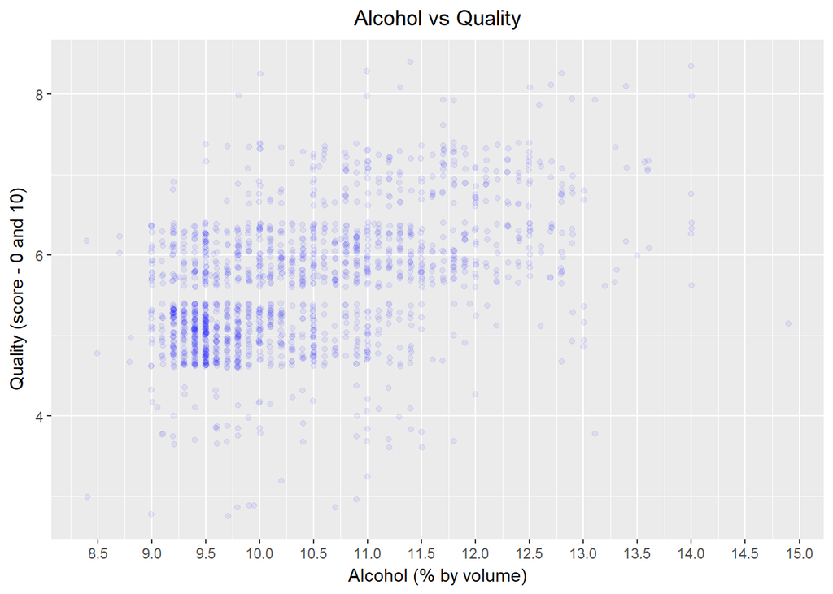

### Description Two

This plot (quality vs alcohol) gives an insight about the quality of the wine - Greater the percentage of alcohol greater the quality.

### Plot Three

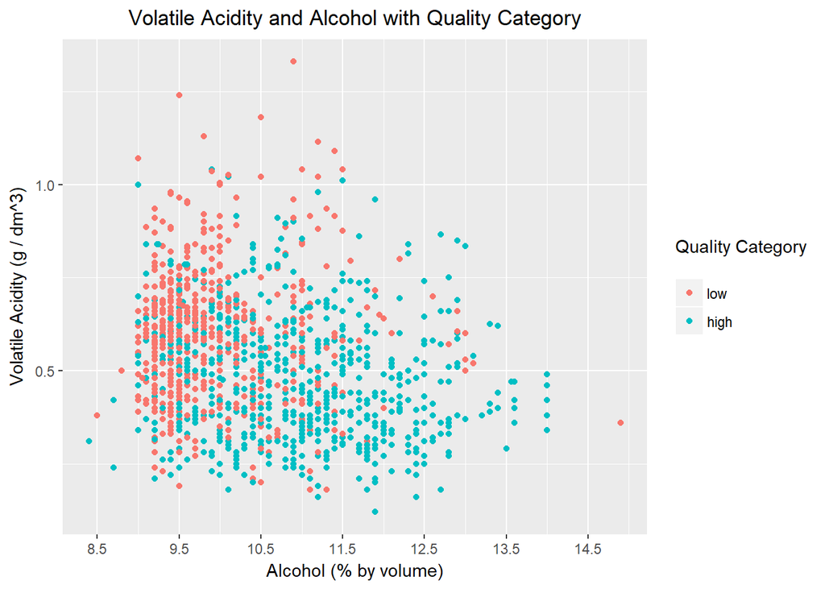

### Description Three

Alcohol and Volatile acidity are the two variables which explain the 31.7% of the variability in the quality score. In our previous findings, we saw how the volatile acidity had a negative correlation which can be seen in this plot, lesser the volatile acidity better the quality. Similarly, with the alcohol, the only difference is that it is positively correlated with the quality.

Note: We can only infer the above statement. Having a low volatile acidity and a high percentage of alcohol doesn’t necessarily means the quality will be good. There are other factors that can have an effect on the quality of the wine.

# Reflection

With the plot matrix, I got a clear idea of how the variables are related to one another. This matrix showed how alcohol was strongly correlated to the quality of the wine, it also helped me in selecting the variables of my interest which saved a lot of time as exploring every variable could have been tedious. I plotted some scatter plot between two variables to visualize how the variables are correlated.

In the multivariate analysis, it visualized with the categorical variable which I created in the earlier part of my exploration. The categorical variable helped in getting an insight of the quality of wine while exploring different variables at once. Finally, I created a linear model to predict the quality of the wine across different variables. Alcohol and Volatile acidity account for 31.7% of the variation in the quality. One of the most surprising things was when I found out that citric acid didn’t improve the quality of the wine.

As all the variables were either numbers or integers I initially struggle to create a categorical variable so that I could explore further - I was finding it hard to think of a categorical variable. Eventually, I did it using the quality variable.

Further, I could have explored the outlier as there were outliers in most of the variables.

Limitations in our exploration: As with our liner model I could only justify the 31.7% of variation in the quality by two variables if I would have had some more details about of the wine I could have done more in finding out the variability of the quality, The data was described in 2009 and as things changes over the time today this correlation of alcohol and volatile acidity might not be the same in today’s world.

# Reference

- ggpair documentation for plot matrix [here](https://www.rdocumentation.org/packages/GGally/versions/1.4.0/topics/ggpairs).
- About Linear Model.
- About [Correlation](https://www.surveysystem.com/correlation.htm).
- ggplot documentation [here](https://www.rdocumentation.org/packages/ggplot2/versions/3.0.0).